# TP Noté Domaine d’application

Tommy Tankhapanya / Chloé Landais/ Samuel Guibert

18/03/2021

```r
#Chargement des packages
library(tidyverse)
library(gridExtra)
library(ggpubr)
library(reshape2)
library(esquisse)
library(plotly)
library(mice)
library(car)
library(questionr)
library(BEST)
library(rstanarm) # bays
library(bayestestR) # bays
library(insight) # bays
# Importation des donnees
data <- read_csv("echantillon_petit.csv")
data_clean = read_csv("data_sport_clean")
```

#### Notre jeu de données est constitué de 100 000 observations et de 39 variables. Il traite du “powerlefting”. C’est une discipline non olympique qui consiste à lever une charge la plus lourde possible sur une répétition de 3 mouvements.

- Squat: Ce mouvement consiste à descendre en en positiopn accroupie et à se relever, une barre reposant sur l’arrière des épaules.
- Développé couché: L’athlète est en postion allongée. Il tient la barre, bras tendus au-dessus de la poitrine, l’amène au contact de la poitrine et la relève.
- Souvelé de terre: L’athlète saisit la barre au sol et la soulève jusqu’à ce que qu’il soit complètement debout, la barre restant au niveau des hanches.

#### La performance est quantifiée par la somme de des meilleurs résultats sur chacun des trois mouvements le jour de la compétition.

# 1. Mise en forme et nettoyage des données

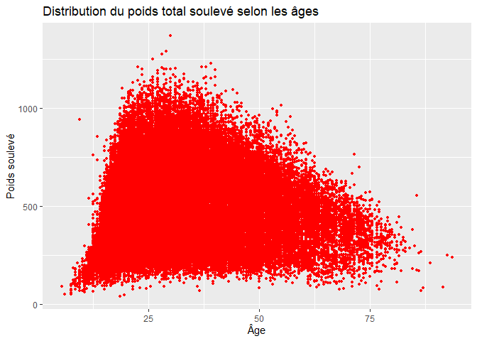

```r
data <- data%>%filter(Age > 5)
ggplot(data, aes(Age, TotalKg)) + geom_point(col = "red", size = 1) +
  labs(title = "Distribution du poids total soulevé selon les âges", x = "Âge", y = "Poids soulevé")
```

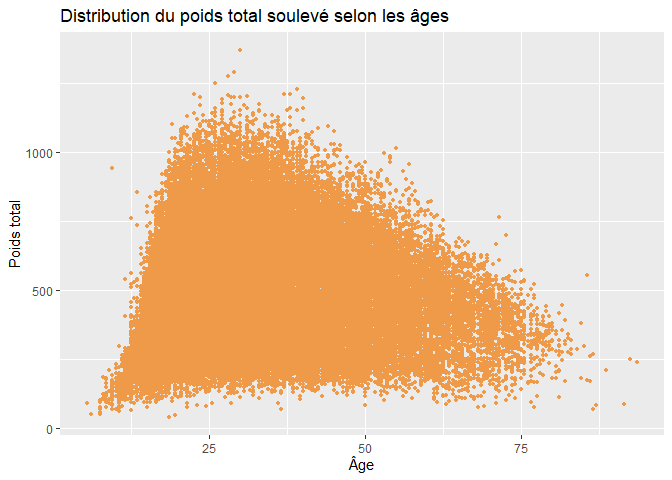

```r
data <- data %>% filter(Age > 5)
ggplot(data, aes(Age, TotalKg)) + geom_point(col = "tan2", size = 1) +
  labs(title = "Distribution du poids total soulevé selon les âges", x = "Âge", y = "Poids total")
```

```r
datasansJoe <- data[-which(data$Name=="Joe Reeves" & data$Age ==9.5),]
```

#### Pour pouvoir visualiser nos données, nous avons d’abord réalisé un nuage de points entre l’âge et le poids total soulevé de chaque haltérophile. Nous pouvons voir qu’il y a certaines données abérantes comme l’observation située à gauche, qui signifierait qu’une personne de 9.5 ans aurait soulevé environ 950 kg. Nous venons de vérifier le nom de cet individu, il se trouve qu’il s’agit de JOE REEVES, cependant nous avons décidé de le supprimer car nous n’avons pas réussi à trouver son age.

#### Nous avons aussi regardé si les performances des meilleurs atlthétes étaient possibles physiquement en nous documentant et nous avons trouvé aucune autre valeurs abberante.

```r
colSums(is.na(datasansJoe))
```

```
##            Name             Sex           Event       Equipment             Age
##               0               0               0               0               0
##        AgeClass        Division    BodyweightKg   WeightClassKg        Squat1Kg
##               0             811              80             331            2665
##        Squat2Kg        Squat3Kg        Squat4Kg    Best3SquatKg        Bench1Kg
##            3696            6201           99249            3301             287
##        Bench2Kg        Bench3Kg        Bench4Kg    Best3BenchKg     Deadlift1Kg
##            1111            3845           99275             718             255
##     Deadlift2Kg     Deadlift3Kg     Deadlift4Kg Best3DeadliftKg         TotalKg
##            1647            5701           98851             558            2227
##           Place           Wilks       McCulloch    Glossbrenner       IPFPoints
##               0            2307            2307            2307            4904
##          Tested         Country      Federation            Date     MeetCountry
##           22243           58075               0               0               0
##       MeetState        MeetName              id        na_count
##           46988               0               0               0
```

```r
# imputation mediane pour les variables utilise
#datasansJoe$BodyweightKg=ifelse(is.na(datasansJoe$BodyweightKg),median(datasansJoe$BodyweightKg),datasansJoe$BodyweightKg)

# imputation avec mice()
#input = mice(datasansJoe,m=5)
#input$imp$BodyweightKg
#data_clean = complete(input,5)
data_clean = read_csv("data_sport_clean") # pour éviter que les valeurs changent à chaque fois
colSums(is.na(data_clean))
```

```
##              X1            Name             Sex           Event       Equipment
##               0               0               0               0               0
##             Age        AgeClass        Division    BodyweightKg   WeightClassKg
##               0               0             811               0             331
##        Squat1Kg        Squat2Kg        Squat3Kg        Squat4Kg    Best3SquatKg
##               0               0               0               0               0
##        Bench1Kg        Bench2Kg        Bench3Kg        Bench4Kg    Best3BenchKg
##               0               0               0               0               0
##     Deadlift1Kg     Deadlift2Kg     Deadlift3Kg     Deadlift4Kg Best3DeadliftKg
##               0               0               0               0               0
##         TotalKg           Place           Wilks       McCulloch    Glossbrenner
##               0               0               0               0               0
##       IPFPoints          Tested         Country      Federation            Date
##               0           22243           58075               0               0
##     MeetCountry       MeetState        MeetName              id        na_count
##               0           46988               0               0               0
```

#### Nous avons aussi regardé s’il y avait beaucoup de valeurs manquantes(NA) dans notre jeu de données. Nous avons hésité entre imputer les valeurs manquantes pour les variables qui nous intéressent par la médiane car celle-ci possède de bonnes propriétées. En effet, la solution la plus simple aurait été de supprimer les données mais avec cette technique on perd de l’information. Au final, nous avons utilisé la fonction mice() du package du même nom qui combine différente méthode d’amputations.

```r
data_clean_dead = filter(data_clean,Best3DeadliftKg>0 )
data_clean_Bench = filter(data_clean,Best3BenchKg>0 )
data_clean_Squat = filter(data_clean,Best3SquatKg>0 )
```

#### Nous avons supprimé les lignes où les athlètes ont ratés toutes leurs séries.

# 2. Description des données (âge,sexe,poids)

## Distribution du sexe

```r
dim(data_clean)
```

```
## [1] 99989    40
```

```r
round(prop.table(table(data$Sex)),3)
```

```
##
##     F     M
## 0.303 0.697
```

```r
label = c("Femme","Homme")
value = c(69683,30307 )
values = c(0.303, 0.697 )

dat = as.data.frame(rbind(label,values))
colnames(dat)=   c("Homme","Femme")
gg3 = plot_ly(dat,labels=label,values=~values  ,type='pie')
gg3 %>% layout(title = "Distribution du sexe des sportifs")
```

[interactive chart not shown]

#### Au sein de notre jeu de données final, on a 30,3% de femmes et 69.7% d’hommes.

## Distribution de l’âge et le poids

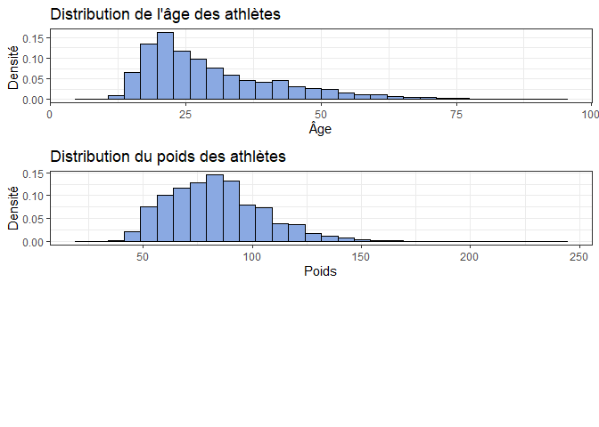

```r
gg1 = ggplot(data_clean, aes(x=Age)) + geom_histogram(aes(y=..count../sum(..count..)), colour="black", fill="#8AA9E2")+ labs(title="Distribution de l'âge des athlètes ",y="Densité ",x="Âge")+theme_bw()

gg2 = ggplot(data_clean, aes(x=BodyweightKg)) + geom_histogram(aes(y=..count../sum(..count..)), colour="black", fill="#8AA9E2")+labs(title = "Distribution du poids des athlètes", x = "Poids", y = "Densité")+theme_bw()

grid.arrange(gg1, gg2,  ncol = 1, nrow = 3)
```

```r
#summary(data_clean$Age)
summary(data_clean$BodyweightKg)
```

```
##    Min. 1st Qu.  Median    Mean 3rd Qu.    Max.
##   21.77   66.60   81.44   83.51   97.50  240.00
```

#### Concernant l’âge, la majorité des atlhètes ont entre 20 et 36 ans. La moyenne d’âge est d’environ 30 ans. 50 % des athlètes ont plus de 26 ans. L’athlète le plus jeune a 5,5 ans et le plus âgé a 93,5 ans.

#### Concernant le poids, la majorité des atlhètes pèsent entre 66.6 et 97.5 kg. Le poids moyen est d’environ 83.51 ans. 50 % des athlètes pèsent plus de 81.44 kg. L’athlète le plus léger pèse 21.77 kg et le plus lourd 240kg.

## Distribution de l’âge et le poids selon le sexe

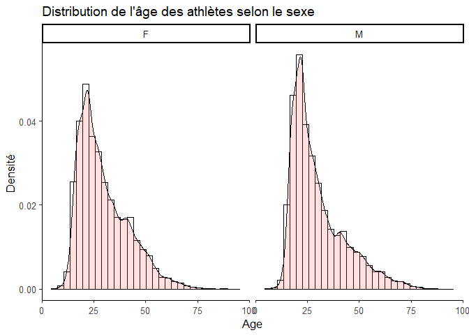

```r
ggplot(data_clean, aes(x=data_clean$Age)) +
  geom_histogram(aes(y=..density..), colour="black", fill="white")+
  geom_density(alpha=.2, fill="#FF6666") + labs(title="Distribution de l'âge des athlètes selon le sexe ",y="Densité ",x="Age")+ theme_classic2()+
 facet_wrap(vars(Sex))
```

```r
data_clean %>% group_by(Sex) %>% summarise("Age moyen" = round(mean(Age),2),"25%" = quantile(Age,probs = 0.25),"Mediane" = round(median(Age),2),"75%" = quantile(Age,probs = 0.75),min=min(Age),max=max(Age))
```

```
## # A tibble: 2 x 7
##   Sex   `Age moyen` `25%` Mediane `75%`   min   max
##   <chr>       <dbl> <dbl>   <dbl> <dbl> <dbl> <dbl>
## 1 F            29.7  20.5    26.5  37     5.5  91.5
## 2 M            30.0  20.5    26    36.5   6    93.5
```

#### D’après les graphiques et le tableau, la distribution de l’âge est très similaire quelque soit le sexe.

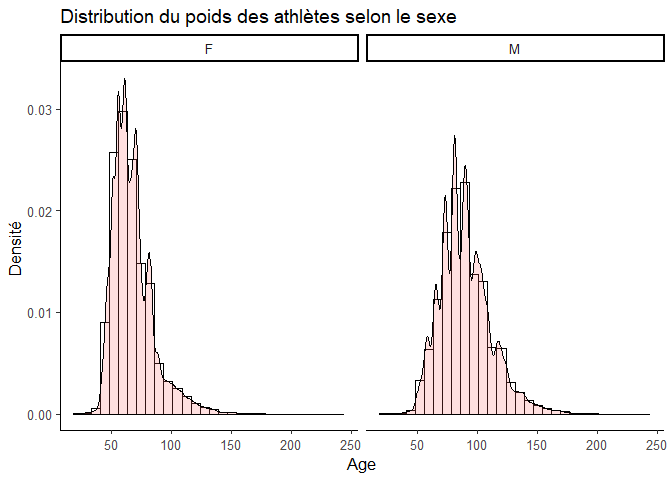

```r
ggplot(data_clean, aes(x=data_clean$BodyweightKg)) +
  geom_histogram(aes(y=..density..), colour="black", fill="white")+
  geom_density(alpha=.2, fill="#FF6666") + labs(title="Distribution du poids des athlètes selon le sexe ",y="Densité ",x="Age")+ theme_classic2()+
 facet_wrap(vars(Sex))
```

```r
 data_clean %>% group_by(Sex) %>% summarise("Poids moyen" = round(mean(BodyweightKg),2),"25%" = quantile(BodyweightKg,probs = 0.25),"Mediane" = round(median(BodyweightKg),2),"75%" = quantile(BodyweightKg,probs = 0.75),min=min(BodyweightKg),max=max(BodyweightKg))
```

```
## # A tibble: 2 x 7
##   Sex   `Poids moyen` `25%` Mediane `75%`   min   max
##   <chr>         <dbl> <dbl>   <dbl> <dbl> <dbl> <dbl>
## 1 F              68.0  56.1    64.7   75   24    184.
## 2 M              90.2  74.4    88.7  102.  21.8  240
```

#### Sans surprise, les hommes sont majoritairement plus lourds que les femmes. En effet, on remarque que 75% des hommes pèsent plus de 74.4 kg alors que chez les femmes ce chiffre est de 56.1 kg. Le poids moyen des hommes est de 90.25 kg et 68.02 kg pour les femmes.

```r
#data_clean_F= filter(data_clean,Sex=='F')
#data_clean_H= filter(data_clean,Sex=='M')
#BESTout = BESTmcmc(data_clean_F$BodyweightKg, data_clean_H$BodyweightKg)
#plot(BESTout)
# trop long a charger
```

#### Distribution de la performance

## Squat

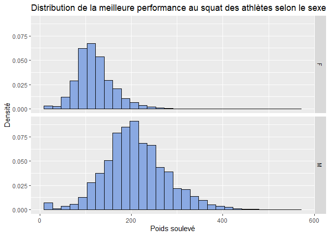

```r
 ggplot(data_clean_Squat, aes(Best3SquatKg)) + geom_histogram(aes(y=..count../sum(..count..)), colour="black", fill="#8AA9E2") +
  labs(title = "Distribution de la meilleure performance au squat des athlètes selon le sexe", x = "Poids soulevé", y = "Densité") + facet_grid(Sex ~.)
```

```r
data_clean_Squat %>% group_by(Sex) %>% summarise("Squat moyen" = round(mean(Best3SquatKg),2),"25%" = quantile(Best3SquatKg,probs = 0.25),"Mediane" = round(median(Best3SquatKg),2),"75%" = quantile(Best3SquatKg,probs = 0.75),min=min(Best3SquatKg),max=max(Best3SquatKg))
```

```
## # A tibble: 2 x 7
##   Sex   `Squat moyen` `25%` Mediane `75%`   min   max
##   <chr>         <dbl> <dbl>   <dbl> <dbl> <dbl> <dbl>
## 1 F              119.    95     115   140  10.5   345
## 2 M              209.   165     205   250  10.5   555
```

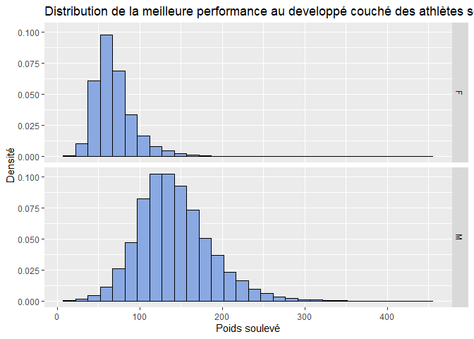

```r
ggplot(data_clean_Bench, aes(Best3BenchKg)) + geom_histogram(aes(y=..count../sum(..count..)), colour="black", fill="#8AA9E2")+
  labs(title = "Distribution de la meilleure performance au developpé couché des athlètes selon le sexe", x = "Poids soulevé", y = "Densité") + facet_grid(Sex ~.)
```

```r
data_clean_Bench %>% group_by(Sex) %>% summarise("Bench moyen" = round(mean(Best3BenchKg),2),"25%" = quantile(Best3BenchKg,probs = 0.25),"Mediane" = round(median(Best3BenchKg),2),"75%" = quantile(Best3BenchKg,probs = 0.75),min=min(Best3BenchKg),max=max(Best3BenchKg))
```

```
## # A tibble: 2 x 7
##   Sex   `Bench moyen` `25%` Mediane `75%`   min   max
##   <chr>         <dbl> <dbl>   <dbl> <dbl> <dbl> <dbl>
## 1 F               68   52.5     65   78.1   9.1  240
## 2 M              142. 112.     138. 168.   10.5  442.
```

#### On passe à présent sur les performances des hommes et des femmes sur l’épreuve du développé couché. Les femmes soulèvent en moyenne sur cette épreuve 68 kg. Tandis que chez les hommes, le poids moyen soulevé est de 141.94 kg. La masse la plus lourdes portées par les hommes est de 442.5 kg et 240 kg chez les femmes. La majorité des femmes font une performance comprise entre 52.5 et 78.125 kg. Pour les hommes, leur performance sont principalement entre 112.5 et 167.5 kg. On remarque à nouveau une assez grande différences entre les hommes et les femmes. Les femmes ont tendance à soulever des poids plus légers.

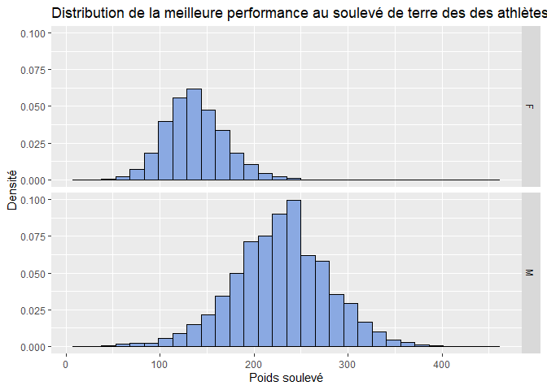

```r
ggplot(data_clean_dead, aes(Best3DeadliftKg)) +  geom_histogram(aes(y=..count../sum(..count..)), colour="black", fill="#8AA9E2") +labs(title = "Distribution de la meilleure performance au soulevé de terre des des athlètes selon le sexe", x = "Poids soulevé", y = "Densité") + facet_grid(Sex ~.)
```

```r
data_clean_dead %>% group_by(Sex) %>% summarise("Deadlift moyen" = round(mean(Best3DeadliftKg),2),"25%" = quantile(Best3DeadliftKg,probs = 0.25),"Mediane" = round(median(Best3DeadliftKg),2),"75%" = quantile(Best3DeadliftKg,probs = 0.75),min=min(Best3DeadliftKg),max=max(Best3DeadliftKg))
```

```
## # A tibble: 2 x 7
##   Sex   `Deadlift moyen` `25%` Mediane `75%`   min   max
##   <chr>            <dbl> <dbl>   <dbl> <dbl> <dbl> <dbl>
## 1 F                 137.   115     135  155   18.1  295
## 2 M                 229.   195     230  262.  25    458.
```

#### Pour finir, on étudie les différentes performance pour le soulevé de terre. Les femmes soulèvent en moyenne sur cette épreuve 136.95 kg. Tandis que chez les hommes, le poids moyen soulevé est de 228.56 kg. La masse la plus lourdes portées par les hommes est de 457.5 kg et 295 kg chez les femmes. La majorité des femmes font une performance comprise entre 115 et 155 kg. Pour les hommes, leur performance sont principalement entre 195 et 262.5 kg. On observe que les athlètes soulèvent des poids plus lourds sur cette épreuve et que les femmes ont tendance à soulever des poids plus légers que les hommes.

#### Quelque soit l’épreuve, la distribution de la performance est toujours en gausienne. Ainsi, la médiane et toujours proche de la moyenne. De manière générale, les hommes soulèvent davantage que les femmes.

# 3.Analyse de la relation âge-performance

## L’âge au pic de la performance au développé selon le sexe

```r
# modele Roger Moore
MMC=function(age,vitesse,methode,nbpara,precision=10,borne=-Inf, initial=runif(nbpara)){

  SQ_methode=function(p){ #Cette fonction permet de calculer la somme carre des residus            #theta sont les parametre qu
    sum((vitesse-methode(age,p))^2) }

  o=rep(10^6,precision) #o permet de stocker la fonction objectif qu'on voudra le plus bas
  r=rep(0,precision) #r permet de sotcker le R?
  para=rep(10^6,precision*(nbpara+1)) #pour stocker tout les parametres
  for (i in seq(nbpara+1,precision*(nbpara+1),nbpara+1)){
    sol=nlminb(start=initial + rnorm(nbpara,0,sqrt(abs(initial))),SQ_methode)
    res= nlminb(start = sol$par,SQ_methode,lower=borne)
    para[i:(i+nbpara-1)]=res$par #ici"
    o[i/(nbpara+1)]=res$objective}
  compt=which.min(o)
  parametre=rep(0,nbpara)
  parametre=para[((nbpara+1)*compt):(((nbpara+1)*compt)+(nbpara-1))] #on stock les meilleurs parametres
  fit=methode(age,parametre) #regression
  R2=sum((fit-mean(vitesse))^2)/sum((vitesse-mean(vitesse))^2) #R?
  peak=age[methode(sort(age),parametre)==max(methode(sort(age),parametre))]
  return(list(parametre=parametre,objectif=min(o),R2=R2,peak=peak))}
f=function(x,p){
  p[1]*(1-exp(p[2]*x))+p[3]*(1-exp(p[4]*x))
}

# creation de dataset filtre selon le sexe
femme <- data_clean %>% filter(Sex == "F")
max_femme_B <- aggregate(data = femme, Best3BenchKg ~ Age, FUN = "max")

homme <- data_clean %>% filter(Sex == "M")
max_homme_B <- aggregate(data = homme, Best3BenchKg ~ Age, FUN = "max")

max_femme_B$Sexe = "F"
max_homme_B$Sexe = "M"
totmax_B <- rbind(max_femme_B, max_homme_B)
```

## L’âge au pic de la performance au développé couché pour les femmes

```r
modelmoore=MMC(max_femme_B$Age,max_femme_B$Best3BenchKg,f,4,precision=5000)
summary(modelmoore)
```

```
##           Length Class  Mode
## parametre 4      -none- numeric
## objectif  1      -none- numeric
## R2        1      -none- numeric
## peak      1      -none- numeric
```

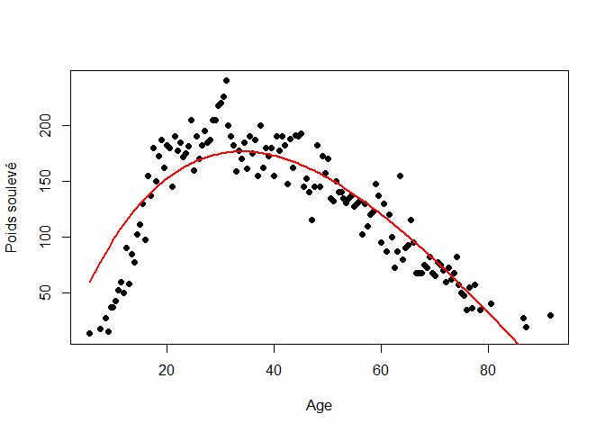

```r
# graphique Moore
plot(max_femme_B$Age,max_femme_B$Best3BenchKg, pch=16, col="black",xlab="Age",ylab = "Poids soulevé")
predictions<-f(max_femme_B$Age,modelmoore$parametre) # calcul des valeurs predites par le modele
lines(max_femme_B$Age,predictions, col="red", lwd=2)
```

```r
max(predictions)
```

```
## [1] 176.6128
```

```r
modelmoore$peak
```

```
## [1] 34
```

```r
max_femme1_B = cbind(max_femme_B, predictions)

tmp = arrange(max_femme1_B,desc(predictions)) %>% slice(1) #34 ans
tmp
```

```
##   Age Best3BenchKg Sexe predictions
## 1  34          170    F    176.6128
```

#### Sur la discipline du developpé couché, les femmes font leurs meilleurs performances entre 32 et 38 ans. L’âge théorique pour faire la meilleur performance selon la méthode de Moore est de 34 ans chez les femmes.

## L’âge au pic de la performance au développé couché pour les hommes

```r
modelmoore=MMC(max_homme_B$Age,max_homme_B$Best3BenchKg,f,4,precision=5000)
summary(modelmoore)
```

```
##           Length Class  Mode
## parametre 4      -none- numeric
## objectif  1      -none- numeric
## R2        1      -none- numeric
## peak      1      -none- numeric
```

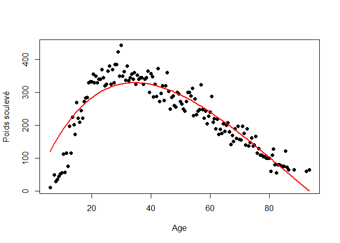

```r
# graphique Moore
plot(max_homme_B$Age,max_homme_B$Best3BenchKg, pch=16, col="black",xlab="Age",ylab = "Poids soulevé")
predictions<-f(max_homme_B$Age,modelmoore$parametre) # calcul des valeurs predites par le modele
lines(max_homme_B$Age,predictions, col="red", lwd=2)
```

```r
max(predictions)
```

```
## [1] 329.2982
```

```r
modelmoore$peak
```

```
## [1] 34.5
```

```r
max_homme1_B = cbind(max_homme_B, predictions)

tmp = arrange(max_homme1_B,desc(predictions)) %>% slice(1) #34,5 ans
tmp
```

```
##    Age Best3BenchKg Sexe predictions
## 1 34.5          360    M    329.2982
```

#### Sur la discipline du developpé couché, les hommes font leurs meilleurs performances entre 30 et 37 ans. L’âge théorique pour faire la meilleur performance selon la méthode de Moore est de 34,5 ans chez les hommes

## L’âge au pic sur la performance totale des trois mouvements

```r
femme <- data_clean %>% filter(Sex == "F")
max_femme <- aggregate(data = femme, TotalKg ~ Age, FUN = "max")

homme <- data_clean %>% filter(Sex == "M")
max_homme <- aggregate(data = homme, TotalKg ~ Age, FUN = "max")

max_femme$Sexe = "F"
max_homme$Sexe = "M"
totmax <- rbind(max_femme, max_homme)


#ggplot(totmax, aes(Age,TotalKg)) + geom_point(fill = "burlywood", col = "red") +labs(title = "Distribution de la meilleure performance au soulevé de terre des des athlètes selon le sexe", x = "Poids soulevé", y = "Nombre d'individus") + facet_grid(Sexe ~.)
```

## L’âge au pic sur la performance totale des trois mouvements pour les femmes

```r
modelmoore=MMC(max_femme$Age,max_femme$TotalKg,f,4,precision=5000)
summary(modelmoore)
```

```
##           Length Class  Mode
## parametre 4      -none- numeric
## objectif  1      -none- numeric
## R2        1      -none- numeric
## peak      1      -none- numeric
```

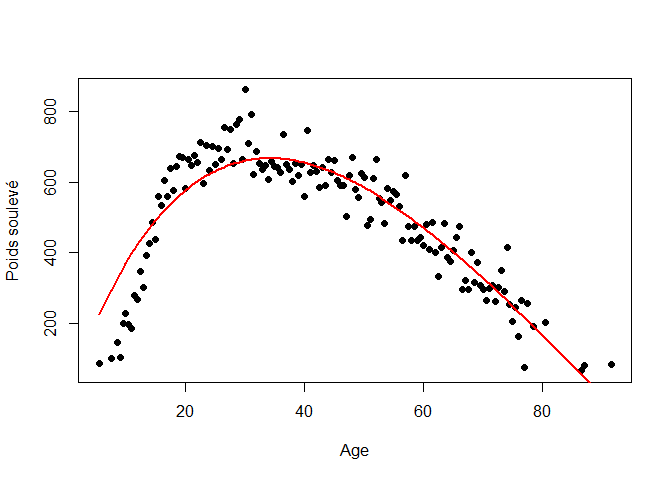

```r
# graphique Moore
plot(max_femme$Age,max_femme$TotalKg, pch=16, col="black",xlab="Age",ylab = "Poids soulevé")
predictions<-f(max_femme$Age,modelmoore$parametre) # calcul des valeurs predites par le modele
lines(max_femme$Age,predictions, col="red", lwd=2)
```

```r
max(predictions)
```

```
## [1] 666.8698
```

```r
predictions
```

```
##   [1] 226.71603 294.78866 326.17298 341.22379 355.85508 370.07280 383.88284
##   [8] 397.29101 410.30305 422.92462 435.16134 447.01875 458.50232 469.61746
##  [15] 480.36950 490.76374 500.80539 510.49960 519.85146 528.86601 537.54822
##  [22] 545.90300 553.93520 561.64961 569.05098 576.14397 582.93323 589.42330
##  [29] 595.61870 601.52389 607.14327 612.48119 617.54195 622.32979 626.84890
##  [36] 631.10343 635.09746 638.83503 642.32014 645.55673 648.54868 651.29986
##  [43] 653.81405 656.09501 658.14645 659.97201 661.57533 662.95996 664.12944
##  [50] 665.08724 665.83680 666.38152 666.72476 666.86982 666.81997 666.57845
##  [57] 666.14844 665.53310 664.73552 663.75879 662.60593 661.27993 659.78376
##  [64] 658.12033 656.29252 654.30317 652.15511 649.85109 647.39385 644.78611
##  [71] 642.03052 639.12972 636.08631 632.90286 629.58191 626.12594 622.53744
##  [78] 618.81884 614.97255 611.00093 606.90634 602.69109 598.35746 593.90770
##  [85] 589.34404 584.66867 579.88376 574.99145 569.99385 564.89304 559.69107
##  [92] 554.38997 548.99174 543.49836 537.91177 532.23390 526.46664 520.61186
##  [99] 514.67141 508.64711 502.54075 496.35412 490.08895 483.74698 477.32990
## [106] 470.83940 464.27712 457.64470 450.94376 444.17589 437.34264 430.44557
## [113] 423.48619 416.46603 409.38655 402.24921 395.05547 387.80674 380.50443
## [120] 373.14991 365.74455 358.28970 350.78668 343.23680 335.64134 328.00157
## [127] 320.31875 312.59411 304.82887 297.02423 289.18136 281.30143 273.38560
## [134] 265.43499 257.45072 249.43388 241.38557 233.30684 225.19876 217.06234
## [141] 208.89863 192.49330 159.39828  58.36045  49.85301 -27.06908
```

```r
modelmoore$peak
```

```
## [1] 34
```

```r
max_femme1 = cbind(max_femme, predictions)

tmp = arrange(max_femme1,desc(predictions)) %>% slice(1) #34 ans
tmp
```

```
##   Age TotalKg Sexe predictions
## 1  34   607.5    F    666.8698
```

#### Sur la performance totale des trois disciplines, les femmes font leurs meilleurs performances environ entre 29 et 37. L’âge théorique pour faire la meilleur performance selon la méthode de Moore est de 34 ans ans chez les femmes.

## L’âge au pic sur la performance totale des trois mouvements pour les hommes

```r
modelmoore=MMC(max_homme$Age,max_homme$TotalKg,f,4,precision=5000)
summary(modelmoore)
```

```
##           Length Class  Mode
## parametre 4      -none- numeric
## objectif  1      -none- numeric
## R2        1      -none- numeric
## peak      1      -none- numeric
```

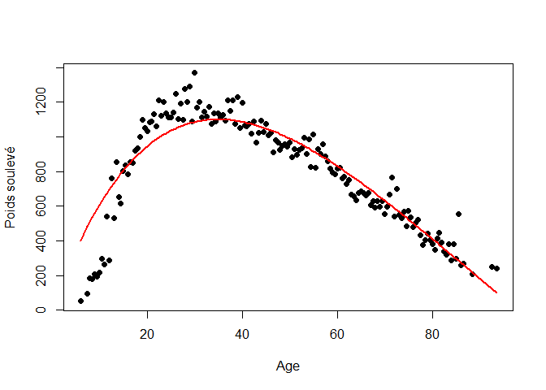

```r
# graphique Moore
plot(max_homme$Age,max_homme$TotalKg, pch=16, col="black",xlab="Age",ylab = "Poids soulevé")
predictions<-f(max_homme$Age,modelmoore$parametre) # calcul des valeurs predites par le modele
lines(max_homme$Age,predictions, col="red", lwd=2)
```

```r
max(predictions)
```

```
## [1] 1099.914
```

```r
modelmoore$peak
```

```
## [1] 35
```

```r
max_homme1 = cbind(max_homme, predictions)

tmp = arrange(max_homme1,desc(predictions)) %>% slice(1) #35 ans
tmp
```

```
##   Age TotalKg Sexe predictions
## 1  35    1135    M    1099.914
```

#### Quelque soit le sexe ou l’épreuve, l’âge théorique pour faire la meilleur performance est d’environ 35 ans.

# 4. Influence du poids sur la performance

```r
# Importation du jeu de données
force=read.csv2('ffforce.csv',sep=',',dec = '.')
#colSums(is.na(force))
force$TotalKg = ifelse(is.na(force$TotalKg),median(force$TotalKg,na.rm = T),force$TotalKg)
# cut
force = mutate(force,Poids = case_when(
  BodyweightKg >40 & BodyweightKg<=60 ~ "(40-60]" ,
  BodyweightKg >60 & BodyweightKg<=70 ~ "(60-70]" ,
  BodyweightKg >70 & BodyweightKg<=80 ~ "(70-80]" ,
   BodyweightKg >80 & BodyweightKg<=90 ~ "(80-90]" ,
  BodyweightKg >90 & BodyweightKg<=100 ~ "(90-100]" ,
  BodyweightKg >100  ~ "100+"
))
table(force$Poids)
```

```
##
##  (40-60]  (60-70]  (70-80]  (80-90] (90-100]     100+
##      322      283      231      260      184      198
```

```r
min(force$BodyweightKg) # valeur mini 42 donc 40 pour la plus petite classe
```

```
## [1] 42.12
```

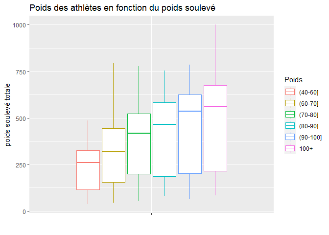

```r
ggplot(force,aes(y=TotalKg,x='',color=Poids))+geom_boxplot()+labs(x="" ,title="Poids des athlètes en fonction du poids soulevé ",y="poids soulevé totale")
```

```r
force %>% group_by(Poids) %>% summarise("Moyenne" = round(mean(TotalKg),2),"25%" = quantile(TotalKg,probs = 0.25),"Mediane" = round(median(TotalKg),2),"75%" = quantile(TotalKg,probs = 0.75),min=min(TotalKg),max=max(TotalKg))
```

```
## # A tibble: 6 x 7
##   Poids    Moyenne `25%` Mediane `75%`   min   max
##   <chr>      <dbl> <dbl>   <dbl> <dbl> <dbl> <dbl>
## 1 (40-60]     237.  116.    259.  324.  37.5  485
## 2 (60-70]     310.  155     318.  445   45    792.
## 3 (70-80]     379.  199.    418.  522.  55    778.
## 4 (80-90]     409.  188.    466.  582.  82.5  755
## 5 (90-100]    445.  203.    535   626.  65    785
## 6 100+        470.  215     559.  675   85   1000
```

#### On se demande si la performance dépend du poids de l’athlète. Pour cette tâche, nous avons regroupé les poids en différentes catégories. Sur le graphique, on observe que plus la catégorie comporte des poids elevé plus la performance est bonne. Pour continuer, nous allons procéder à une ANOVA.

```r
reg = lm(TotalKg~Poids, data= force)
summary(reg)
```

```
##
## Call:
## lm(formula = TotalKg ~ Poids, data = force)
##
## Residuals:
##     Min      1Q  Median      3Q     Max
## -384.86 -167.48   27.68  150.18  530.14
##
## Coefficients:
##               Estimate Std. Error t value Pr(>|t|)
## (Intercept)     237.48      10.11  23.492  < 2e-16 ***
## Poids(60-70]     72.35      14.78   4.895 1.09e-06 ***
## Poids(70-80]    141.35      15.64   9.038  < 2e-16 ***
## Poids(80-90]    171.37      15.12  11.331  < 2e-16 ***
## Poids(90-100]   207.35      16.76  12.369  < 2e-16 ***
## Poids100+       232.38      16.38  14.185  < 2e-16 ***
## ---
## Signif. codes:  0 '***' 0.001 '**' 0.01 '*' 0.05 '.' 0.1 ' ' 1
##
## Residual standard error: 181.4 on 1472 degrees of freedom
## Multiple R-squared:  0.1706, Adjusted R-squared:  0.1678
## F-statistic: 60.55 on 5 and 1472 DF,  p-value: < 2.2e-16
```

#### L’intercept est le poids moyen soulevé au total par les athlètes ayant un poids compris entre 40 et 60, c’est à dire 237.48 kg. Pour obtenir, l’espèrance du poids moyen soulevé au total pour les athlètes ayant un poids compris entre 90 et 100. Il faut faire la somme 237.48 + 207.35 = 444.83. Ainsi, un athlète ayant un poids de plus de 100kg soulève en moyenne 232.38kg de plus que ceux ayant un poids compris entre 40 et 60kg en moyenne.

#### Plus le poids augmente plus, le poids soulevé au total augmente.

#### On souhaite à présent réaliser une anova. Pour cela, nous devons vérifier les trois conditions suivantes :

- 1. Les résidus sont indépendants.

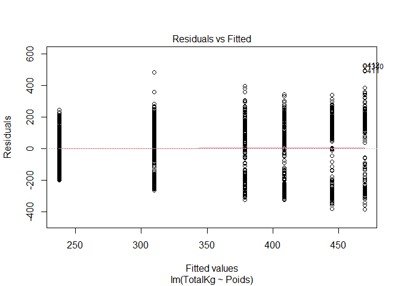

```r
plot(reg, 1)
```

```r
durbinWatsonTest(reg)
```

```
##  lag Autocorrelation D-W Statistic p-value
##    1       0.8682222      0.262497       0
##  Alternative hypothesis: rho != 0
```

- 2. Les residus de la variable quantitative étudiée suit une loi normale de moyenne 0 dans les p populations comparées.

```r
shapiro.test(reg$residuals)
```

```
##
##  Shapiro-Wilk normality test
##
## data:  reg$residuals
## W = 0.95717, p-value < 2.2e-16
```

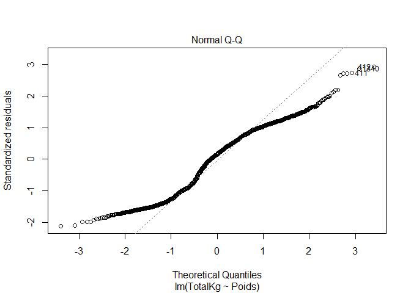

```r
plot(reg, 2)
```

- 3. Les p populations comparées ont même variance : Homogénéité des variances ou homoscédasticité.

```r
leveneTest(force$TotalKg~force$Poids)
```

```
## Levene's Test for Homogeneity of Variance (center = median)
##         Df F value    Pr(>F)
## group    5   44.52 < 2.2e-16 ***
##       1472
## ---
## Signif. codes:  0 '***' 0.001 '**' 0.01 '*' 0.05 '.' 0.1 ' ' 1
```

```r
bartlett.test(force$TotalKg~force$Poids)
```

```
##
##  Bartlett test of homogeneity of variances
##
## data:  force$TotalKg by force$Poids
## Bartlett's K-squared = 158.49, df = 5, p-value < 2.2e-16
```

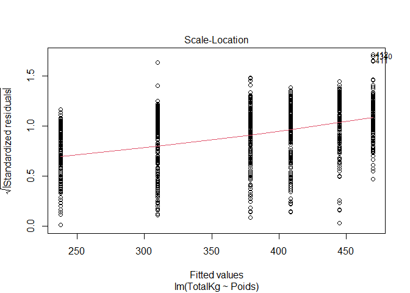

```r
plot(reg,3)
```

#### D’après le graphique et le test de Berthelet ou de levene, on rejette l’égalité des variances. En effet, la p-valeur du test est très inférieur à 5% .

```r
analyse = anova(reg)
analyse
```

```
## Analysis of Variance Table
##
## Response: TotalKg
##             Df   Sum Sq Mean Sq F value    Pr(>F)
## Poids        5  9961979 1992396  60.552 < 2.2e-16 ***
## Residuals 1472 48434466   32904
## ---
## Signif. codes:  0 '***' 0.001 '**' 0.01 '*' 0.05 '.' 0.1 ' ' 1
```

```r
#summary(analyse)
```

#### D’après les différents tests, les hypothèses ne sont pas toutes réunies d’où un possible biais, cependant, l’anova reste une analyse solide.

#### L’ANOVA nous permet de voir que la variable poids totale soulevé a des valeurs différentes en fonction des différents groupes de poids. Plus le poids augmente, plus le poids soulevé augmente. En effet, la p-valeur est très significative. L’anova nous confirme l’intuition du graphique concernant le poids soulevé selon les catégories de poids.

#### En conclusion, le poids à une influence sur la performance. Plus le poids augmente plus la performance augmente.

# 5. Equipements

#### Il est possible d’utiliser plusieurs équipement en powerlifting (variable:equipment):

- raw:sans équipement
- Simple-ply:combinaisonàunecouche
- Multi-ply:combinaisonàplusieurscouches
- Straps:Bande élastique pour fixer le poignet à la barre
- Wraps:Bande élastique autour des articulations

## Création de la classe

```r
## Recodage de data$TotalKg en data$TotalKg_rec
data_clean$PoidsTotal <- cut(data_clean$TotalKg,
  include.lowest = T,
  right = TRUE,
  dig.lab = 4,
  breaks = c(0 ,310,400, 500,580,680,1500)
)

table(data_clean$PoidsTotal) # nombre assez homogene
```

```
##
##    [0,310]  (310,400]  (400,500]  (500,580]  (580,680] (680,1500]
##      17384      16094      17909      15979      16398      16225
```

```r
#data_clean %>% select(Equipment) %>% distinct()
```

## Test du Chi²

#### Afin d’estimer si l’équipement à une influence sur la performance, nous allons procéder à un test du $\chi^2$ d’indépendance :

#### Nous avons comme hypothèse nulle $(H_0)$ et alternative $(H_1)$ :

$(H_0)$ : X et Y $\perp$ contre $(H_1)$ : X et Y liées

#### Les conditions d’utilisation de ce test sont les suivantes :

- Les effectifs théoriques sous $H_0$ sont suffisament grands
- Le nombre d’observations doit être suffisament grand
- $\forall_i,_j \in${$1,\dots,k$}*{$1,\dots,l$}

```r
Tab_contingence <- table(data_clean$PoidsTotal, data_clean$Equipment)
Tab_contingence
```

```
##
##              Multi-ply   Raw Single-ply Wraps
##   [0,310]          240 11749       3079  2316
##   (310,400]        311  9435       4294  2054
##   (400,500]        496  9822       4996  2595
##   (500,580]        481  8872       4019  2607
##   (580,680]        732  7686       4986  2994
##   (680,1500]      2114  3522       7663  2926
```

#### Ici, les conditions sont validées, nous allons donc procéder au test :

```r
chisq.test(Tab_contingence)
```

```
##
##  Pearson's Chi-squared test
##
## data:  Tab_contingence
## X-squared = 10589, df = 15, p-value < 2.2e-16
```

#### La $p-valeur$ est très proche de 0, d’après le test du $\chi^2$ les deux variables sont liées. C’est à dire que la performance est lié à l’utilisation d’un équipement.

#### Fort de ce constat, nous allons observé quel e l’équipement qui favorise au maximun les performances. Pour cela, nous allons analyser les résidus du test :

```r
perf<- chisq.test(Tab_contingence)
perf$residuals
```

```
##
##                Multi-ply         Raw  Single-ply       Wraps
##   [0,310]    -18.8733531  30.4237860 -27.7170954  -7.2724177
##   (310,400]  -14.8125328  13.3692955  -5.5544605  -8.8024860
##   (400,500]  -10.2689694   7.0252196  -2.8399610  -3.4126982
##   (500,580]   -8.2454646   7.8365801  -9.1211507   2.6380513
##   (580,680]    0.5478322  -7.5602862   3.2458716   8.9940073
##   (680,1500]  52.7091293 -52.3641454  42.9942836   8.2201853
```

#### Le *Raw* favoriserait la performance des atlhètes portant des charges plus légères.

#### Il est intéressant de noter qu’a à certain niveau, il est presque obligatoire de porter des équipements pour protéger et préserver ses articulations. Comme par exemple, avec la ceinture abdominale au soulevé de terre.